# Topic statement: "A Study on the Characteristics of Elderly Residents in Singapore"

Name: Konda Sai Srikar Reddy  
Student ID: P2426053  
Title: PDS CA2  
Topic: A Study on the characteristics of elderly residents in singapore

DATASET 1: https://data.gov.sg/datasets/d_c24f6b8078ee721f7191906ca1b3a367/view  
DATASET 2: https://data.gov.sg/datasets/d_995d47e4632e72e4f0a589ed5e51bd36/view  
DATASET 3: https://data.gov.sg/datasets/d_1a5bb230195b27f5982682d4bb66bcb0/view  
DATASET 4: https://data.gov.sg/datasets/d_6c678a9e6cf49086c1fea012c40ceafe/view  
DATASET 5: https://data.gov.sg/datasets/d_4180067b350bc9839a4cea487841d5d1/view  
DATASET 6: https://data.gov.sg/datasets/d_76eb0a0d52db203284c50ccfba84c815/view  
DATASET 7: https://data.gov.sg/datasets/d_326034ad1aa58165096567150dd8bde9/view

QUESTIONS:  
Question 1: What are the proportions of elderly of different age groups by year?  
Question 2: How does the gender distribution of elderly residents vary across different age groups?  
Question 3: What is the distribution of elderly across different ambulant status categories in the most recent year?  
Question 4: How does the distribution of elderly population percentages differ across ethnic groups over the years?  
Question 5: How does the distribution of elderly residents vary by flat type over the years?  
Question 6: How does the distribution of the elderly population vary across different towns over the years?  
Question 7: How does the marital-status composition of elderly residents differ by sex in the most recent year?  
Question 8: How has the distribution of elderly residents across housing tenure types changed between 2013 and the most recent year?

Sources I used to research:  
https://pmc.ncbi.nlm.nih.gov/articles/PMC5119869/  
https://www.sgpc.gov.sg/api/file/getfile/Press%20Release%20-%20CLT%202023-2024.pdf?path=/sgpcmedia/media_releases/singstat/press_release/P-20250527-2/attachment/Press%20Release%20-%20CLT%202023-2024.pdf  
https://www.forwardsingapore.gov.sg/chapters/chapter-5  
https://amp.org.sg/wp-content/uploads/2017/06/12-Section-9_Demographic-Study.pdf  
https://www.singstat.gov.sg/-/media/files/publications/population/ssn122-pg6-9.ashx  
https://www.singstat.gov.sg/-/media/files/publications/population/ssnsep10-pg25-29.pdf  
https://www.straitstimes.com/singapore/singapores-population-ageing-rapidly-184-of-citizens-are-65-years-and-older  
https://ourworldindata.org/why-do-women-live-longer-than-men  
https://www.scientificamerican.com/article/why-is-life-expectancy-lo/  
https://www.bbc.com/future/article/20151001-why-women-live-longer-than-men  
https://wifehealth.com/why-is-female-life-expectancy-higher-than-male/

```python
import numpy as np
import matplotlib.pyplot as plt
import pandas as pd
import seaborn as sns
```

# Question 1: what are the proportions of elderly of different age groups by year

```python
# Load the dataset from the CSV file into a Pandas DataFrame
df = pd.read_csv("HDBElderlyandFutureElderlyResidentPopulationbyAgeandSex.csv")

# Print the shape (rows, columns) of the dataset
print("Shape of dataset:", df.shape)

# Print the column names as a Python list
print("\nColumn Names:", df.columns.tolist())

# Print the data types of each column
print("\nData Types:\n", df.dtypes)

# Print the first 5 rows of the dataset
print("\nFirst 5 rows:\n", df.head())

# --- Summary Statistics using Pandas ---
print("\nBasic Statistics for 'percentage':")
print("Mean:", df['percentage'].mean())       # Average
print("Median:", df['percentage'].median())   # Middle value
print("Minimum:", df['percentage'].min())     # Smallest value
print("Maximum:", df['percentage'].max())     # Largest value

# Print all unique years found in the 'shs_year' column
print("\nUnique Years:", df['shs_year'].unique())

# Print the smallest and largest year in the dataset
print("Year Range:", (df['shs_year'].min(), df['shs_year'].max()))

# Print all unique elderly population types in the 'elderly_pop' column
print("\nUnique Elderly Population Types:", df['elderly_pop'].unique())

# Print all unique values in the 'sex' column
print("Unique Sex Values:", df['sex'].unique())

# Print all unique age groups in the 'age' column
print("Unique Age Groups:", df['age'].unique())
```

```
Shape of dataset: (42, 5)

Column Names: ['shs_year', 'elderly_pop', 'sex', 'age', 'percentage']

Data Types:
 shs_year         int64
elderly_pop     object
sex             object
age             object
percentage     float64
dtype: object

First 5 rows:
    shs_year elderly_pop   sex         age  percentage
0      2013     Elderly  Male   65  -  69        40.2
1      2013     Elderly  Male   70  -  74        29.9
2      2013     Elderly  Male   75  -  79        18.9
3      2013     Elderly  Male   80  -  84         6.9
4      2013     Elderly  Male  85 & Above         4.1

Basic Statistics for 'percentage':
Mean: 28.571428571428573
Median: 27.5
Minimum: 4.1
Maximum: 55.1

Unique Years: [2013 2018]
Year Range: (2013, 2018)

Unique Elderly Population Types: ['Elderly' 'Future Elderly']
Unique Sex Values: ['Male' 'Female' 'All']
Unique Age Groups: ['65  -  69' '70  -  74' '75  -  79' '80  -  84' '85 & Above' '55  -  59'
 '60  -  64']
```

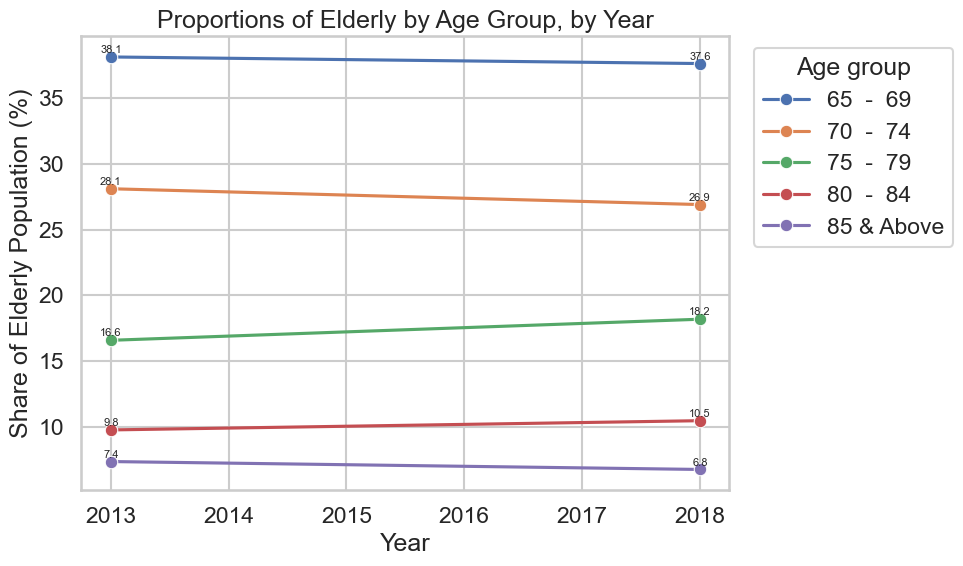

```python
# Define the display order for age groups
age_order = ["65  -  69", "70  -  74", "75  -  79", "80  -  84", "85 & Above"]

# Filter only elderly population with 'All' sexes
elderly = df[(df["elderly_pop"] == "Elderly") & (df["sex"] == "All")].copy()

# Function to add labels to each point on the plot
def add_point_labels(ax, fmt="{:.1f}"):
    for line in ax.lines:  # Loop through lines in the plot
        x_data = line.get_xdata()  # Get x coordinates
        y_data = line.get_ydata()  # Get y coordinates
        for x, y in zip(x_data, y_data):  # Loop through each point
            ax.text(x, y + 0.3, fmt.format(y), ha='center', fontsize=8)  # Add label

# Create a new figure with given size
plt.figure(figsize=(10, 6))

# Plot a line graph with seaborn
ax = sns.lineplot(
    data=elderly,
    x="shs_year",
    y="percentage",
    hue="age",
    marker="o"
)

# Set x-axis label
plt.xlabel("Year")

# Set y-axis label
plt.ylabel("Share of Elderly Population (%)")

# Set plot title
plt.title("Proportions of Elderly by Age Group, by Year")

# Show legend outside the plot
plt.legend(title="Age group", bbox_to_anchor=(1.02, 1), loc="upper left")

# Add point labels to the plot
add_point_labels(ax)

# Adjust layout to prevent overlaps
plt.tight_layout()

# Add grid lines
plt.grid(True)

# Display the plot
plt.show()
```

The graph shows the proportions of elderly by age group from 2013 to 2018. The 65–69 age group consistently has the largest share, starting at 38.1 percent in 2013 and remaining almost unchanged at 37.6 percent in 2018. The 70–74 group is the second largest, beginning at 28.1 percent and decreasing slightly to 26.9 percent over the same years. The 75–79 group shows a gradual increase, rising from 16.6 percent to 18.2 percent. The 80–84 group also grows slightly, moving from 9.8 percent in 2013 to 10.5 percent in 2018. Finally, the 85 and above group has the smallest share throughout the period, starting at 7.4 percent and dipping to 6.8 percent by 2018.

https://pmc.ncbi.nlm.nih.gov/articles/PMC5119869/

The graph shows that the 65–69 age group makes up the largest share of the elderly population in Singapore between 2013 and 2018. Life expectancy at age 65 for Singapore residents has increased from 16 years in 1995 to 20 years in 2011 This means that, on average, someone reaching 65 can expect to live to about 85. As a result, the 65–69 group dominates the graph because it includes all those just entering old age, while the 70–74, 75–79, and 80–84 groups still hold significant shares since many continue to live well past 65. However, the 85+ group remains much smaller because even with rising life expectancy, fewer survive far beyond 85, making this age band the least represented among the elderly population.

From 2013 to 2018, the 65–69 age group remains the largest share but shows a slight decline from 38.1% to 37.6%. The 70–74 group also decreases gradually from 28.1% to 26.9%. In contrast, the 75–79 group increases steadily from 16.6% to 18.2%, while the 80–84 group rises slightly from 9.8% to 10.5%. The 85 & above group shows a small decline from 7.4% to 6.8%. Overall, the trend indicates that while the younger elderly groups (65–69 and 70–74) are slowly shrinking in share, the older groups (75–79 and 80–84) are growing, reflecting a gradual shift towards an older elderly population, with the 85+ group remaining the smallest and slightly declining.

# Question 2: “How does the gender distribution of elderly residents vary across different age groups?”

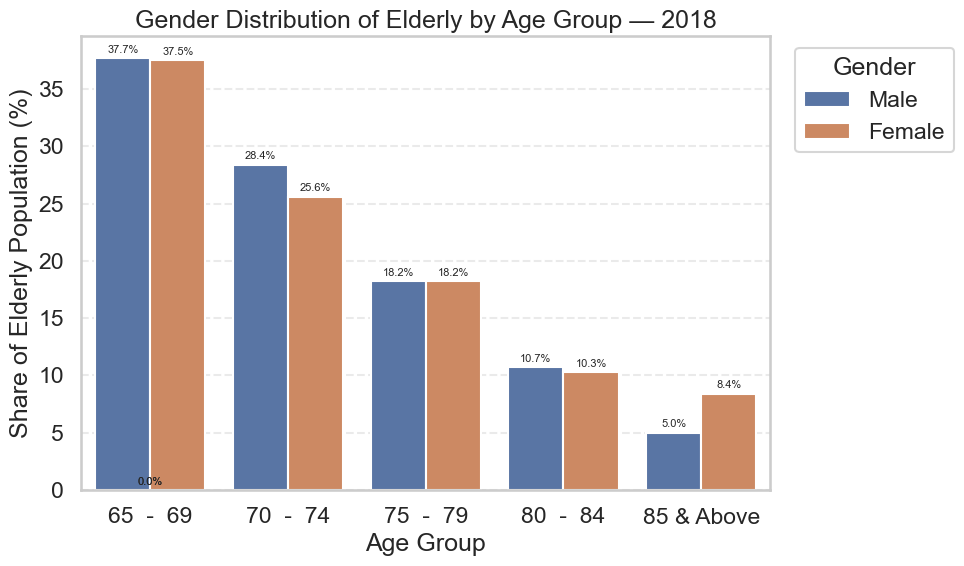

```python
# ---------------------------------------------
# 1) Display order for age groups
# ---------------------------------------------
age_order = ["65  -  69", "70  -  74", "75  -  79", "80  -  84", "85 & Above"]

# ---------------------------------------------
# 2) Filter to Elderly and Male/Female only
# ---------------------------------------------
elderly = df[(df["elderly_pop"] == "Elderly") & (df["sex"].isin(["Male", "Female"]))].copy()

# ---------------------------------------------
# 3) Focus on latest year
# ---------------------------------------------
latest_year = elderly["shs_year"].max()
elderly_latest = elderly[elderly["shs_year"] == latest_year].copy()

# ---------------------------------------------
# 4) Helper to add labels on bars
# ---------------------------------------------
def add_bar_labels(ax, fmt="{:.1f}%"):
    for bar in ax.patches:                      # loop over bars
        h = bar.get_height()                    # bar height
        x = bar.get_x() + bar.get_width()/2     # center x
        ax.text(x, h + 0.3, fmt.format(h),      # label just above
                ha="center", va="bottom", fontsize=8)

# ---------------------------------------------
# 5) Plot grouped bars by age and sex
# ---------------------------------------------
plt.figure(figsize=(10, 6))                     # new figure
ax = sns.barplot(                               # grouped barplot
    data=elderly_latest,
    x="age",
    y="percentage",
    hue="sex",
    order=age_order,
    errorbar=None
)

# ---------------------------------------------
# 6) Labels, title, legend
# ---------------------------------------------
plt.xlabel("Age Group")                         # x label
plt.ylabel("Share of Elderly Population (%)")   # y label
plt.title(f"Gender Distribution of Elderly by Age Group — {latest_year}")  # title
plt.legend(title="Gender", bbox_to_anchor=(1.02, 1), loc="upper left")     # legend out

# ---------------------------------------------
# 7) Labels + layout polish
# ---------------------------------------------
add_bar_labels(ax)                              # add bar labels
plt.grid(axis="y", linestyle="--", alpha=0.4)   # light grid
plt.tight_layout()                               # avoid overlap
plt.show()                                       # display
```

In 2018, the gender distribution of the elderly in Singapore shows that males and females are almost equal in the 65–69 age group, with 37.7 percent for males and 37.5 percent for females. In the 70–74 group, males make up a slightly larger share at 28.4 percent compared to 25.6 percent for females. The 75–79 group is balanced, with both genders at 18.2 percent, while the 80–84 group is also nearly equal at 10.7 percent for males and 10.3 percent for females. However, in the 85 and above group, the distribution shifts, with females holding a larger share at 8.4 percent compared to 5.0 percent for males.

https://www.sgpc.gov.sg/api/file/getfile/Press%20Release%20-%20CLT%202023-2024.pdf?path=/sgpcmedia/media_releases/singstat/press_release/P-20250527-2/attachment/Press%20Release%20-%20CLT%202023-2024.pdf

"Resident life expectancies at age 65 years improved from 18.8 years in 2014 to 19.5 years in 2024 for males and from 22.1 years in 2014 to 22.7 years in 2024 for females" This line basically says that the life expectancy at 65 of female is always higher than males meaning once they reach 85 and above female population is higher than males which is reflected in graph

# Question 3:"What is the distribution of elderly across different ambulant status categories in the most recent year?"

```python
# Load the dataset from the CSV file into a Pandas DataFrame
df = pd.read_csv("HDBElderlyandFutureElderlyResidentPopulationbyAmbulantStatus.csv")

# Print the shape (rows, columns) of the dataset
print("Shape of dataset:", df.shape)

# Print the column names as a Python list
print("\nColumn Names:", df.columns.tolist())

# Print the data types of each column
print("\nData Types:\n", df.dtypes)

# Print the first 5 rows of the dataset
print("\nFirst 5 rows:\n", df.head())

# --- Summary Statistics using Pandas ---
print("\nBasic Statistics for 'percentage':")
print("Mean:", df['percentage'].mean())       # Average value
print("Median:", df['percentage'].median())   # Middle value
print("Minimum:", df['percentage'].min())     # Smallest value
print("Maximum:", df['percentage'].max())     # Largest value
print("Standard Deviation:", df['percentage'].std())  # Spread of values

# Print all unique years found in the 'shs_year' column
print("\nUnique Years:", df['shs_year'].unique())

# Print the smallest and largest year in the dataset
print("Year Range:", (df['shs_year'].min(), df['shs_year'].max()))

# Print all unique elderly population types in the 'elderly_pop' column
print("\nUnique Elderly Population Types:", df['elderly_pop'].unique())

# Print all unique values in the 'ambulant_status' column
print("Unique Ambulant Status Categories:", df['ambulant_status'].unique())
```

```
Shape of dataset: (30, 4)

Column Names: ['shs_year', 'elderly_pop', 'ambulant_status', 'percentage']

Data Types:
 shs_year             int64
elderly_pop         object
ambulant_status     object
percentage         float64
dtype: object

First 5 rows:
    shs_year elderly_pop                                    ambulant_status  \
0      2008     Elderly                  Ambulant & Physically Independent
1      2008     Elderly  Ambulant & Physically Independent but Require ...
2      2008     Elderly    Require Some Physical Assistance to Move Around
3      2008     Elderly  Not Bedridden but Require Total Physical Assis...
4      2008     Elderly         Bedridden & Require Regular Turning in Bed

   percentage
0        87.4
1         7.2
2         3.8
3         1.3
4         0.3

Basic Statistics for 'percentage':
Mean: 20.0
Median: 1.25
Minimum: 0.1
Maximum: 98.4
Standard Deviation: 37.31251985501695

Unique Years: [2008 2013 2018]
Year Range: (2008, 2018)

Unique Elderly Population Types: ['Elderly' 'Future Elderly']
Unique Ambulant Status Categories: ['Ambulant & Physically Independent'
 'Ambulant & Physically Independent but Require Walking Aids'
 'Require Some Physical Assistance to Move Around'
 'Not Bedridden but Require Total Physical Assistance'
 'Bedridden & Require Regular Turning in Bed']
```

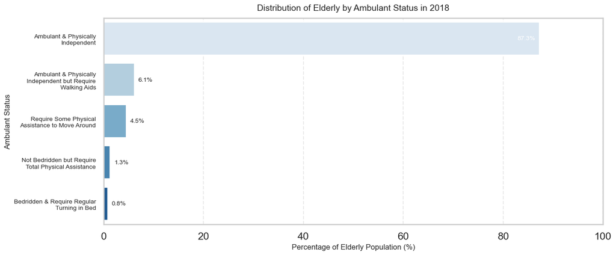

```python
# --------------------------------------------
# Helper: wrap long y-axis labels into lines
# --------------------------------------------
def wrap_labels(labels, max_len=30):
    wrapped = []                                              # List to collect wrapped strings
    for lbl in labels:                                        # Loop through each original label
        if len(lbl) <= max_len:                               # If label fits within max length
            wrapped.append(lbl)                               # Keep as-is
        else:                                                 # Otherwise, wrap on spaces
            parts, line, words = [], "", lbl.split()          # Prepare containers and split words
            for w in words:                                   # Loop through words to build lines
                if len(line) + len(w) + 1 <= max_len:         # If word fits in current line
                    line = (line + " " + w).strip()           # Append word to current line
                else:                                         # If word doesn't fit
                    parts.append(line)                        # Save completed line
                    line = w                                  # Start a new line
            parts.append(line)                                # Add the final line
            wrapped.append("\n".join(parts))                  # Join lines with newline
    return wrapped                                            # Return wrapped labels list

# ---------------------------------------------------------
# Helper: add labels inside wide bars, outside narrow bars
# ---------------------------------------------------------
def add_smart_labels(ax, fmt="{:.1f}%"):
    for bar in ax.patches:                                    # Loop through all drawn bars
        width = bar.get_width()                               # Get bar length (percentage value)
        y = bar.get_y() + bar.get_height() / 2                # Compute vertical center for text
        txt = fmt.format(width)                               # Format text as percentage string
        if width >= 12:                                       # If bar is wide enough for inside text
            ax.text(width - 0.8, y, txt,                      # Place text inside the bar
                    va="center", ha="right", color="white", fontsize=10)
        else:                                                 # Otherwise, place text just outside
            ax.text(width + 0.8, y, txt,                      # Place text outside the bar
                    va="center", ha="left", fontsize=10)

# ---------------------------------------------------------
# 1) Prepare data for latest year (kept simple and explicit)
# ---------------------------------------------------------
elderly = df[df["elderly_pop"] == "Elderly"].copy()           # Filter dataset to elderly rows only
latest_year = int(elderly["shs_year"].max())                  # Extract the most recent year
latest = elderly[elderly["shs_year"] == latest_year].copy()   # Keep rows for that latest year
latest = latest.sort_values("percentage", ascending=True)     # Sort ascending for top-heavy layout
latest = latest.reset_index(drop=True)                        # Reset index after sorting

# ---------------------------------------------------------
# 2) Create figure and draw the horizontal bar plot
# ---------------------------------------------------------
fig, ax = plt.subplots(figsize=(14, 6))                       # Make a wider figure so bars dominate
sns.barplot(                                                  # Draw horizontal bars with Seaborn
    data=latest,
    y="ambulant_status",
    x="percentage",
    hue="ambulant_status",                                    # Assign hue to safely use a palette
    dodge=False,                                              # No grouped bars
    legend=False,                                             # Hide legend (labels already on y-axis)
    palette="Blues_r",
    ax=ax
)

# ---------------------------------------------------------
# 3) Apply wrapped y-tick labels and styling
# ---------------------------------------------------------
ax.set_yticks(range(len(latest)))                             # Fix tick positions to match rows
ax.set_yticklabels(                                           # Apply wrapped labels to reduce width
    wrap_labels(latest["ambulant_status"].tolist(), max_len=30),
    fontsize=10
)

# ---------------------------------------------------------
# 4) Title, axes labels (removed mean reference line stuff)
# ---------------------------------------------------------
ax.set_title(                                                 # Add informative title
    f"Distribution of Elderly by Ambulant Status in {latest_year}",
    pad=12, fontsize=14
)
ax.set_xlabel("Percentage of Elderly Population (%)", fontsize=12)  # Label x-axis
ax.set_ylabel("Ambulant Status", fontsize=12)                        # Label y-axis
ax.invert_yaxis()                                              # Put the largest bar at the top
ax.set_xlim(0, 100)                                            # Fix range to 0–100 (percent scale)

# ---------------------------------------------------------
# 5) Add data labels and final visual polish
# ---------------------------------------------------------
add_smart_labels(ax, fmt="{:.1f}%")                           # Annotate bars with values
ax.grid(axis="x", linestyle="--", alpha=0.4)                  # Add light vertical gridlines
plt.tight_layout()                                            # Tighten layout to avoid clipping
plt.show()                                                    # Render the final plot
```

This graph shows the distribution of elderly in Singapore by ambulant status in 2018. The vast majority of elderly, 87.3 percent, are ambulant and physically independent, meaning they can move around on their own without help. A smaller group, 6.1 percent, are ambulant but require walking aids, while 4.5 percent require some physical assistance to move around. Only 1.3 percent are not bedridden but require total physical assistance, and an even smaller proportion, 0.8 percent, are bedridden and require regular turning in bed. Overall, the graph highlights that most elderly in Singapore remain independent in mobility, with only a small fraction needing significant physical assistance.

https://www.forwardsingapore.gov.sg/chapters/chapter-5

"We will continue to build up our preventive care system through Healthier SG, and bring together multiple stakeholders to empower Singaporeans to live healthier and maintain active lifestyles. Through Age Well SG, we will strengthen our aged care system and enable our seniors to age well in the community. An expanded network of Active Ageing Centres will help seniors stay engaged and socially active by giving them opportunities to contribute to the community. We hope that doctors, healthcare providers and community partners can guide our seniors to keep healthy for as long as possible through a personalised health plan. Community partners can also organise programmes and activities for seniors to participate in and provide a social network for mutual support. We ask that family members, friends and befrienders actively encourage seniors to improve their health and stay active and socially connected. We encourage seniors to do their part in taking responsibility for their own health and well-being, such as by making healthy lifestyle choices, attending regular medical screenings, and participating actively in the community."The graph shows that most elderly in Singapore are still ambulant and physically independent, while only a small share need physical assistance or are bedridden. This connects with initiatives like Healthier SG and Age Well SG, which focus on preventive care, active lifestyles, and community support to help seniors remain healthy and independent for as long as possible. These programmes aim to strengthen the aged care system, encourage regular health screenings, and provide social engagement opportunities, so that more elderly can continue to age well in the community.

# Question 4: How does the distribution of elderly population percentages differ across ethnic groups over the years?

```python
# ---------------------------
# 1) Load dataset and clean column names
# ---------------------------
df = pd.read_csv("HDBElderlyandFutureElderlyResidentPopulationbyEthnicGroup.csv")
# ---------------------------
# 2) Print basic dataset information
# ---------------------------
print("Shape of dataset:", df.shape)                      # Number of rows and columns
print("\nColumn Names:", df.columns.tolist())             # List of all column names
print("\nData Types:\n", df.dtypes)                       # Data type of each column
print("\nFirst 5 Rows:\n", df.head())                     # Preview of first 5 rows

# ---------------------------
# 3) Explore unique values and ranges
# ---------------------------
print("\nUnique values in 'elderly_pop':", df["elderly_pop"].unique())  # Elderly categories
print("Unique ethnic groups:", df["ethnic_group"].unique())             # Ethnic group categories
print("Year range:", (df["shs_year"].min(), df["shs_year"].max()))      # Min and max year

# ---------------------------
# 4) Summary statistics using Pandas
# ---------------------------
print("\nOverall percentage statistics:")
print(" Mean:", df["percentage"].mean())                  # Mean percentage
print(" Median:", df["percentage"].median())              # Median percentage
print(" Minimum:", df["percentage"].min())                # Smallest percentage
print(" Maximum:", df["percentage"].max())                # Largest percentage
print(" Std Dev:", df["percentage"].std())                # Standard deviation

# ---------------------------
# 5) Per-ethnic group summary statistics
# ---------------------------
print("\nMean percentage by ethnic group:")               # Mean % for each ethnic group
print(df.groupby("ethnic_group")["percentage"].mean().round(2))

print("\nMedian percentage by ethnic group:")             # Median % for each ethnic group
print(df.groupby("ethnic_group")["percentage"].median().round(2))
```

```
Shape of dataset: (48, 4)

Column Names: ['shs_year', 'elderly_pop', 'ethnic_group', 'percentage']

Data Types:
 shs_year          int64
elderly_pop      object
ethnic_group     object
percentage      float64
dtype: object

First 5 Rows:
    shs_year     elderly_pop ethnic_group  percentage
0      2003         Elderly      Chinese        80.4
1      2003         Elderly        Malay        12.2
2      2003         Elderly       Indian         6.1
3      2003         Elderly       Others         1.3
4      2003  Future Elderly      Chinese        81.8

Unique values in 'elderly_pop': ['Elderly' 'Future Elderly' 'All']
Unique ethnic groups: ['Chinese' 'Malay' 'Indian' 'Others']
Year range: (2003, 2018)

Overall percentage statistics:
 Mean: 24.995833333333334
 Median: 9.1
 Minimum: 0.6
 Maximum: 84.3
 Std Dev: 31.667816795089873

Mean percentage by ethnic group:
ethnic_group
Chinese    78.60
Indian      6.88
Malay      13.22
Others      1.28
Name: percentage, dtype: float64

Median percentage by ethnic group:
ethnic_group
Chinese    79.45
Indian      6.45
Malay      12.80
Others      1.20
Name: percentage, dtype: float64
```

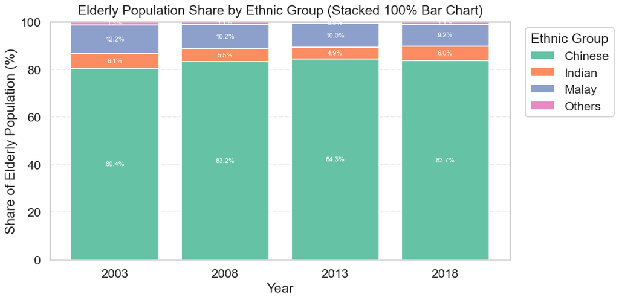

```python
# ---------------------------------------------------------
# Function: Add % labels inside stacked bars (all segments)
# ---------------------------------------------------------
def add_bar_labels(ax, wide_df, fmt="{:.1f}%"):
    # Start with baseline at 0 for all bars
    bottoms = np.zeros(len(wide_df))

    # Loop through each ethnic group (column)
    for col in wide_df.columns:
        vals = wide_df[col].to_numpy()  # Values for this group across years

        # Place a label for each year (row)
        for i, (val, bottom) in enumerate(zip(vals, bottoms)):
            ax.text(
                i,                         # X-position = year index
                bottom + val/2,            # Y-position = middle of this stacked segment
                fmt.format(val),           # Format as percentage text
                ha="center", va="center",  # Center align
                fontsize=9, color="white"  # White text for contrast
            )

        # Update baseline for stacking next group above
        bottoms += vals


# ---------------------------------------------------------
# 1) Filter elderly population data
# ---------------------------------------------------------
eth = df[df["elderly_pop"] == "Elderly"].copy()   # Keep only elderly rows
eth = eth[["shs_year", "ethnic_group", "percentage"]]  # Keep only needed columns

# ---------------------------------------------------------
# 2) Pivot to wide format (years × ethnic groups)
# ---------------------------------------------------------
wide = eth.pivot(
    index="shs_year",          # Rows = years
    columns="ethnic_group",    # Columns = ethnic groups
    values="percentage"        # Values = percentages
).sort_index()                 # Sort by year


# ---------------------------------------------------------
# 3) Plot stacked 100% bar chart
# ---------------------------------------------------------
fig, ax = plt.subplots(figsize=(12, 6))   # Create figure and axis, set size

# Pick distinct colors for each ethnic group
colors = sns.color_palette("Set2", n_colors=len(wide.columns))

# X positions = 0,1,2,... for each year
x = np.arange(len(wide))

# Convert years to string labels for x-axis
years_labels = wide.index.astype(str).tolist()

# Start baseline for stacking
bottom = np.zeros(len(wide))

# Loop through each ethnic group (column) and plot stacked bars
for i, col in enumerate(wide.columns):
    vals = wide[col].to_numpy()                           # Values for this group
    ax.bar(x, vals, bottom=bottom, color=colors[i],       # Stacked bar
           label=col)
    bottom += vals                                        # Update baseline

# ---------------------------------------------------------
# 4) Add titles, labels, grid, legend
# ---------------------------------------------------------
ax.set_title("Elderly Population Share by Ethnic Group (Stacked 100% Bar Chart)", pad=10)
ax.set_xlabel("Year")
ax.set_ylabel("Share of Elderly Population (%)")

# X-axis ticks and labels
ax.set_xticks(x)
ax.set_xticklabels(years_labels, rotation=0)

# Y-axis fixed from 0 to 100%
ax.set_ylim(0, 100)

# Light dashed grid for readability
ax.grid(axis="y", linestyle="--", alpha=0.35)

# Legend placed outside on the right
ax.legend(title="Ethnic Group", loc="upper left", bbox_to_anchor=(1.02, 1))

# ---------------------------------------------------------
# 5) Add percentage labels inside bars
# ---------------------------------------------------------
add_bar_labels(ax, wide, fmt="{:.1f}%")

# ---------------------------------------------------------
# 6) Adjust layout and show chart
# ---------------------------------------------------------
plt.tight_layout()   # Adjust spacing to avoid cutoff
plt.show()           # Display chart
```

The graph shows the elderly population share in Singapore by ethnic group across the years 2003, 2008, 2013, and 2018, using a stacked 100% bar chart. In every year shown, the Chinese elderly form the overwhelming majority, beginning with 80.4 percent in 2003, rising to 83.2 percent in 2008, further increasing slightly to 84.3 percent in 2013, and then settling at 83.7 percent in 2018. The Indian elderly population remains relatively stable over time, starting at 6.1 percent in 2003, dipping to 5.5 percent in 2008, reaching its lowest at 4.9 percent in 2013, before rising again to 6.0 percent in 2018. The Malay elderly population shows a gradual decline across the years, moving from 12.2 percent in 2003, down to 10.2 percent in 2008, 10.0 percent in 2013, and finally 9.2 percent in 2018, indicating a slow but steady reduction in share. The “Others” group, which includes all other ethnic groups outside Chinese, Indian, and Malay, remains consistently very small, hovering around or below 1 percent throughout the years, with almost no noticeable changes across the four time points. Taken together, the chart clearly highlights the consistent dominance of the Chinese group in the elderly population, the stability of the Indian group with only slight fluctuations, the gradual decline of the Malay group, and the consistently negligible proportion represented by other ethnicities.

https://amp.org.sg/wp-content/uploads/2017/06/12-Section-9_Demographic-Study.pdf

"There has been an increasing proportion of singles among Malays from the year 2000 onwards. Singles made up 35% of the Malay population in 2010, up from 29% in 2000. This is the first time Malay singles proportionately surpassed national levels (31%). Moreover, there has also been increasing singlehood at younger ages (e.g. 20+ years old) which is expected to lead to delayed nuptiality and subsequently, fertility declines."The decline in the share of Malay elderly from 12.2% in 2003 to 9.2% in 2018 can be linked to demographic patterns observed within the Malay community. From 2000 onwards, the proportion of Malay singles has been increasing, with 35% recorded in 2010 compared to 29% in 2000, surpassing the national level of 31%. Rising singlehood, especially among younger Malays in their 20s, is associated with delayed marriage and lower fertility rates. Over time, these trends contribute to a smaller proportion of Malays in the elderly population, which is reflected in the gradual decline seen in the graph.

# Question 5: “How does the distribution of elderly residents vary by flat type over the years?”

```python
# ---------------------------
# 1) Load dataset and clean column names
# ---------------------------
df = pd.read_csv("HDBElderlyandFutureElderlyResidentPopulationbyFlatType.csv")  # Read CSV into DataFrame
df.columns = df.columns.str.strip()                                             # Remove stray spaces in headers

# ---------------------------
# 2) Print basic dataset information
# ---------------------------
print("Shape of dataset:", df.shape)                                            # Number of rows and columns
print("\nColumn Names:", df.columns.tolist())                                   # List of all column names
print("\nData Types:\n", df.dtypes)                                             # Data type of each column
print("\nFirst 5 Rows:\n", df.head())                                           # Preview first 5 rows

# ---------------------------
# 3) Explore unique values and ranges
# ---------------------------
print("\nUnique values in 'elderly_pop':", df["elderly_pop"].unique())          # Elderly categories present
print("Unique flat types:", df["flat_type"].unique())                           # HDB flat type categories
print("Year range:", (df["shs_year"].min(), df["shs_year"].max()))              # Minimum and maximum year
# ---------------------------
# 4) Summary statistics using Pandas
# ---------------------------
print("\nOverall percentage statistics:")
print(" Mean:", df["percentage"].mean())                                        # Mean percentage
print(" Median:", df["percentage"].median())                                    # Median percentage
print(" Minimum:", df["percentage"].min())                                      # Smallest percentage
print(" Maximum:", df["percentage"].max())                                      # Largest percentage
print(" Std Dev:", df["percentage"].std())                                      # Standard deviation

# ---------------------------
# 5) Per-flat type summary statistics (all years, all elderly_pop states)
# ---------------------------
print("\nMean percentage by flat type (all rows):")                             # Mean % by flat type
print(df.groupby("flat_type")["percentage"].mean().round(2))

print("\nMedian percentage by flat type (all rows):")                           # Median % by flat type
print(df.groupby("flat_type")["percentage"].median().round(2))
```

```
Shape of dataset: (72, 4)

Column Names: ['shs_year', 'elderly_pop', 'flat_type', 'percentage']

Data Types:
 shs_year         int64
elderly_pop     object
flat_type       object
percentage     float64
dtype: object

First 5 Rows:
    shs_year elderly_pop flat_type  percentage
0      2003     Elderly    1-room         4.6
1      2003     Elderly    2-room         6.3
2      2003     Elderly    3-room        29.6
3      2003     Elderly    4-room        36.4
4      2003     Elderly    5-room        17.7

Unique values in 'elderly_pop': ['Elderly' 'Future Elderly' 'All']
Unique flat types: ['1-room' '2-room' '3-room' '4-room' '5-room' 'Executive']
Year range: (2003, 2018)

Overall percentage statistics:
 Mean: 16.66388888888889
 Median: 13.5
 Minimum: 1.1
 Maximum: 42.1
 Std Dev: 13.506016453350881

Mean percentage by flat type (all rows):
flat_type
1-room        2.73
2-room        3.84
3-room       24.66
4-room       38.75
5-room       22.69
Executive     7.31
Name: percentage, dtype: float64

Median percentage by flat type (all rows):
flat_type
1-room        2.20
2-room        3.65
3-room       23.40
4-room       40.15
5-room       22.25
Executive     7.85
Name: percentage, dtype: float64
```

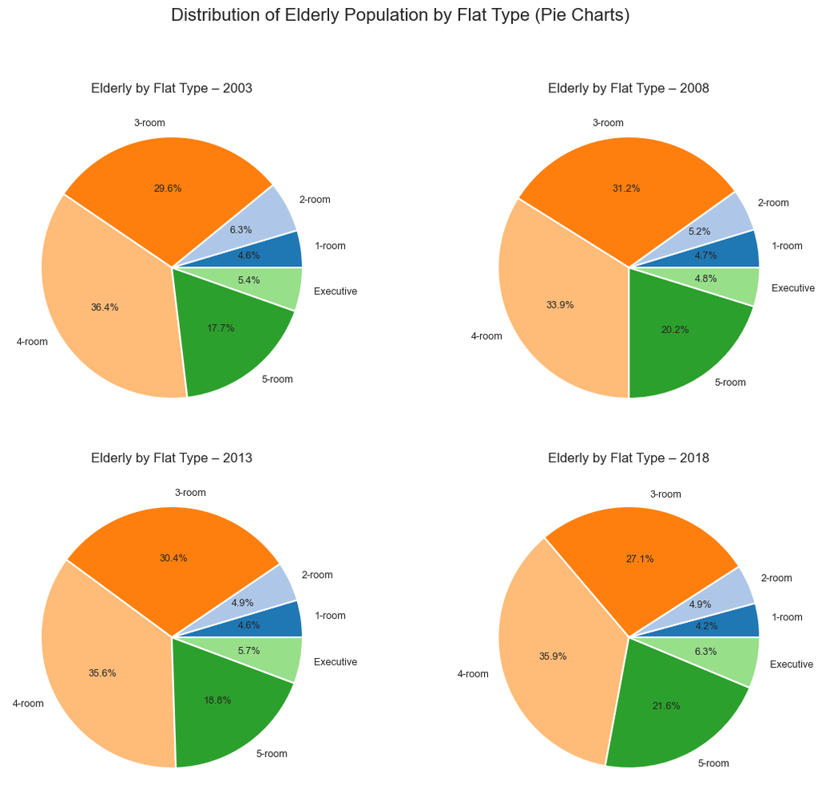

```python
# ---------------------------
# 2) Load and clean dataset
# ---------------------------
df = pd.read_csv("HDBElderlyandFutureElderlyResidentPopulationbyFlatType.csv")  # Load dataset from CSV
df["flat_type"] = df["flat_type"].astype(str).str.strip()                       # Ensure flat_type is string & strip spaces

# ---------------------------
# 3) Keep only elderly rows
# ---------------------------
elderly = df[df["elderly_pop"] == "Elderly"].copy()                             # Filter dataset to elderly population only

# ---------------------------
# 4) Aggregate percentages by year and flat type
# ---------------------------
agg = elderly.groupby(["shs_year", "flat_type"], as_index=False)["percentage"].sum()  # Sum percentages by year & flat type
agg["percentage"] = agg.groupby("shs_year")["percentage"].transform(lambda x: x / x.sum() * 100)
# Re-normalize so percentages add up to 100% for each year

# ---------------------------
# 5) Pick actual years from dataset
# ---------------------------
years = [2003, 2008, 2013, 2018]      # Dataset contains exactly these years
flat_types = [                        # Define fixed order of flat types
    "1-room", "2-room", "3-room",
    "4-room", "5-room", "Executive"
]

# ---------------------------
# 6) Create subplots (2x2 for 4 years)
# ---------------------------
fig, axes = plt.subplots(2, 2, figsize=(12, 10))           # Create 2x2 grid of subplots
axes = axes.flatten()                                      # Flatten 2D array → list for easier iteration

# Consistent colors across pies (map each flat type to a color)
color_map = dict(zip(flat_types, plt.cm.tab20.colors[:len(flat_types)]))
colors_ordered = [color_map[ft] for ft in flat_types]      # Keep order consistent across charts

for ax, year in zip(axes, years):                          # Loop through each subplot with matching year
    # Get data for that year
    s = (agg[agg["shs_year"] == year]                      # Filter rows for the year
         .set_index("flat_type")["percentage"]             # Use flat_type as index, take percentages
         .reindex(flat_types, fill_value=0))               # Reindex to include all flat types in fixed order

    # Plot pie chart for this year
    wedges, texts, autotexts = ax.pie(
        s.values,                                          # Values = percentages for flat types
        labels=flat_types,                                 # Labels = flat type names
        autopct="%.1f%%",                                  # Show % with 1 decimal place
        colors=colors_ordered,                             # Use consistent colors
        textprops={"fontsize": 9}                          # Set font size for labels
    )

    # Add subplot title
    ax.set_title(f"Elderly by Flat Type – {year}", fontsize=12, pad=10)

# ---------------------------
# 7) Global title and layout
# ---------------------------
plt.suptitle("Distribution of Elderly Population by Flat Type (Pie Charts)", fontsize=16, y=1.02)
# Add global title above all subplots
plt.tight_layout()                                        # Adjust layout so plots don’t overlap
plt.show()                                                # Display the figure
```

https://www.singstat.gov.sg/-/media/files/publications/population/ssn122-pg6-9.ashx

# "Question 6: How does the distribution of the elderly population vary across different towns over the years?"

```python
# ---------------------------
# 1) Load dataset and clean column names
# ---------------------------
df = pd.read_csv("HDBElderlyandFutureElderlyResidentPopulationbyGeographicalDistribution.csv")  # Read CSV


# ---------------------------
# 2) Identify key columns (year, elderly flag, geography, value)
# ---------------------------
year_col = "shs_year"                                                                           # Year column
pop_col  = "elderly_pop"                                                                        # Elderly vs Future Elderly
geo_col  = "town_estate"                                                                        # Geography column in this file
val_col  = "number"                                                                             # Counts (not percentages)

# ---------------------------
# 3) Print basic dataset information
# ---------------------------
print("Shape of dataset:", df.shape)                                                            # Rows, cols
print("\nColumn Names:", df.columns.tolist())                                                   # All columns
print("\nData Types:\n", df.dtypes)                                                             # Dtypes per column
print("\nFirst 5 Rows:\n", df.head())                                                           # Preview rows

# ---------------------------
# 4) Explore unique values and ranges
# ---------------------------
print("\nUnique values in 'elderly_pop':", df[pop_col].unique())                                # Elderly categories
print(f"Unique {geo_col} values:", df[geo_col].nunique(), "distinct")                           # Count of towns/estates
print("Sample towns/estates:", sorted(df[geo_col].unique())[:10])                               # First 10 names
print("Year range:", (df[year_col].min(), df[year_col].max()))                                  # Min/max year

# ---------------------------
# 5) Check for nulls
# ---------------------------
print("\nNull counts per column:\n", df.isna().sum())                                           # Nulls per column

# ---------------------------
# 6) Totals by (year, elderly_pop) using counts
# ---------------------------
totals = (df.groupby([year_col, pop_col], as_index=False)[val_col]
            .sum()
            .rename(columns={val_col: "total_count"}))                                          # Yearly totals
print("\nTotals by (year, elderly_pop) — first 10 rows:")
print(totals.head(10))                                                                          # Show a few rows

# ---------------------------
# 7) Summary statistics on counts (Pandas)
# ---------------------------
print("\nOverall COUNT statistics:")                                                            # Basic stats on counts
print(" Mean:", df[val_col].mean())                                                             # Mean
print(" Median:", df[val_col].median())                                                         # Median
print(" Minimum:", df[val_col].min())                                                           # Min
print(" Maximum:", df[val_col].max())                                                           # Max
print(" Std Dev:", df[val_col].std())                                                           # Std dev

# ---------------------------
# 8) Per-town/estate summary stats across all rows
# ---------------------------
print(f"\nMean COUNT by {geo_col} (all rows):")                                                 # Mean counts by town
print(df.groupby(geo_col)[val_col].mean().round(2))

print(f"\nMedian COUNT by {geo_col} (all rows):")                                               # Median counts by town
print(df.groupby(geo_col)[val_col].median().round(2))
```

```
Shape of dataset: (208, 4)

Column Names: ['shs_year', 'elderly_pop', 'town_estate', 'number']

Data Types:
 shs_year        int64
elderly_pop    object
town_estate    object
number          int64
dtype: object

First 5 Rows:
    shs_year elderly_pop  town_estate  number
0      2003     Elderly     Sengkang    6398
1      2003     Elderly      Punggol    1387
2      2003     Elderly    Sembawang    2262
3      2003     Elderly  Jurong West   11885
4      2003     Elderly     Tampines   12200

Unique values in 'elderly_pop': ['Elderly' 'Future Elderly']
Unique town_estate values: 25 distinct
Sample towns/estates: ['Ang Mo Kio', 'Bedok', 'Bishan', 'Bukit Batok', 'Bukit Merah', 'Bukit Panjang', 'Bukit Timah', 'Central Area', 'Choa Chu Kang', 'Clementi']
Year range: (2003, 2018)

Null counts per column:
 shs_year       0
elderly_pop    0
town_estate    0
number         0
dtype: int64

Totals by (year, elderly_pop) — first 10 rows:
   shs_year     elderly_pop  total_count
0      2003         Elderly       217569
1      2003  Future Elderly       247785
2      2008         Elderly       285462
3      2008  Future Elderly       339496
4      2013         Elderly       335091
5      2013  Future Elderly       407238
6      2018         Elderly       502700
```

[output cut: 51 more lines]

```
Hougang            15124.5
Jurong East         8858.0
Jurong West        19094.5
Kallang/Whampoa    15409.5
Marine Parade       3395.5
Pasir Ris          11530.5
Punggol             4338.0
Queenstown         13017.0
Sembawang           4103.0
Sengkang           10968.0
Serangoon           7831.0
Tampines           24702.0
Toa Payoh          15426.0
Yishun             15911.5
Name: number, dtype: float64
```

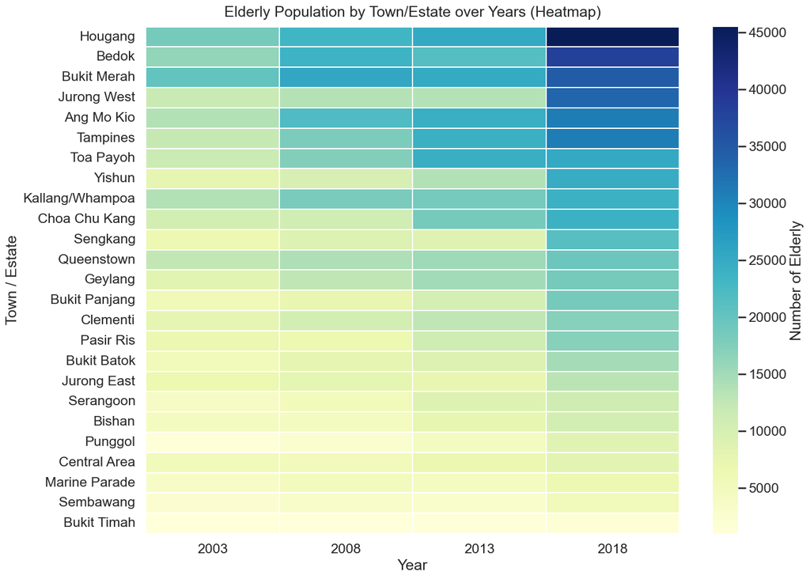

```python
# ---------------------------------------------------------
# 1) Load dataset
# ---------------------------------------------------------
df = pd.read_csv("HDBElderlyandFutureElderlyResidentPopulationbyGeographicalDistribution.csv")

# ---------------------------------------------------------
# 2) Keep elderly population only
# ---------------------------------------------------------
df_elderly = df[df["elderly_pop"] == "Elderly"].copy()

# ---------------------------------------------------------
# 3) Aggregate elderly counts (absolute numbers)
# ---------------------------------------------------------
agg = df_elderly.groupby(["shs_year", "town_estate"], as_index=False)["number"].sum()

# ---------------------------------------------------------
# 4) Pivot to matrix: towns × years (absolute elderly numbers)
# ---------------------------------------------------------
num_mat = agg.pivot(index="town_estate", columns="shs_year", values="number")

# ---------------------------------------------------------
# 5) Order rows by latest year (descending)
# ---------------------------------------------------------
if num_mat.shape[1] > 0:                                  # If there are year columns
    last_year = num_mat.columns.max()                     # Get the most recent year
    sorter = num_mat[last_year].fillna(0)                 # Use that year's values
    num_mat = num_mat.loc[sorter.sort_values(ascending=False).index]

# ---------------------------------------------------------
# 6) Plot heatmap with actual numbers
# ---------------------------------------------------------
plt.figure(figsize=(14, 10))
sns.heatmap(
    num_mat,
    cmap="YlGnBu",
    linewidths=0.3,
    linecolor="white",
    cbar_kws={"label": "Number of Elderly"}   # Now the legend shows counts
)

plt.title("Elderly Population by Town/Estate over Years (Heatmap)", pad=12)
plt.xlabel("Year")
plt.ylabel("Town / Estate")
plt.tight_layout()
plt.show()
```

https://www.singstat.gov.sg/-/media/files/publications/population/ssnsep10-pg25-29.pdf

According to the article "Older estates generally have larger elderly populations. There were three planning areas with more than 20,000 elderly residents aged 65 years and over as at end-June 2010 (Chart 2). Bedok had the largest population of elderly residents with 31,600, followed by Bukit Merah (24,000) and Ang Mo Kio (21,400)."This shows that the reason why estates like bedok and bukit merah have high elderly population is becuase they are old. The elderly probably stayed there when they were young and then chose to stay there after they got old too.

https://www.straitstimes.com/singapore/singapores-population-ageing-rapidly-184-of-citizens-are-65-years-and-older

Another point to take note is that in 2018 the shade is a lot darker than the other years. From the source above we can see that " Singapore's population is ageing rapidly, with the proportion of citizens aged 65 and above increasing to 18.4 per cent in 2022. This is a spike from 11.1 per cent in 2012, said the annual Population In Brief report released on Tuesday. It was 17.6 per cent in 2021."This tells us that this is the oldest singapore has ever been in terms of people

# Question 7: “How does the marital-status composition of elderly residents differ by sex in the most recent year?”

```python
# ---------------------------
# 1) Load dataset and clean column names
# ---------------------------
df = pd.read_csv("HDBElderlyandFutureElderlyResidentPopulationbyMaritalStatus.csv")  # Read CSV into DataFrame


# ---------------------------
# 2) Print basic dataset information
# ---------------------------
print("Shape of dataset:", df.shape)                                                 # Number of rows and columns
print("\nColumn Names:", df.columns.tolist())                                        # List of all column names
print("\nData Types:\n", df.dtypes)                                                  # Data type of each column
print("\nFirst 5 Rows:\n", df.head())                                                # Preview first 5 rows

# ---------------------------
# 3) Explore unique values and ranges
# ---------------------------
print("\nUnique years:", df["shs_year"].unique())                                    # Distinct years
print("Year range:", (df["shs_year"].min(), df["shs_year"].max()))                   # Minimum and maximum year
print("Unique elderly_pop values:", df["elderly_pop"].unique())                      # Elderly vs Future Elderly
print("Unique sex values:", df["sex"].unique())                                      # Male / Female / All
print("Unique marital statuses:", df["marital_status"].unique())                     # Status categories

# ---------------------------
# 6) Summary statistics using Pandas (percentage column)
# ---------------------------
print("\nOverall percentage statistics:")                                             # Print basic stats
print(" Mean:", df["percentage"].mean())                                              # Mean percentage
print(" Median:", df["percentage"].median())                                          # Median percentage
print(" Minimum:", df["percentage"].min())                                            # Smallest percentage
print(" Maximum:", df["percentage"].max())                                            # Largest percentage
print(" Std Dev:", df["percentage"].std())                                            # Standard deviation

# ---------------------------
# 7) Per-marital-status summary statistics (all rows)
# ---------------------------
print("\nMean % by marital status (all rows):")                                       # Mean % for each status
print(df.groupby("marital_status")["percentage"].mean().round(2))

print("\nMedian % by marital status (all rows):")                                     # Median % for each status
print(df.groupby("marital_status")["percentage"].median().round(2))
```

```
Shape of dataset: (96, 5)

Column Names: ['shs_year', 'elderly_pop', 'sex', 'marital_status', 'percentage']

Data Types:
 shs_year            int64
elderly_pop        object
sex                object
marital_status     object
percentage        float64
dtype: object

First 5 Rows:
    shs_year elderly_pop     sex      marital_status  percentage
0      2003     Elderly    Male             Married        79.3
1      2003     Elderly    Male             Widowed        12.4
2      2003     Elderly    Male  Divorced/Separated         3.3
3      2003     Elderly    Male              Single         5.0
4      2003     Elderly  Female             Married        40.9

Unique years: [2003 2008 2013 2018]
Year range: (2003, 2018)
Unique elderly_pop values: ['Elderly' 'Future Elderly']
Unique sex values: ['Male' 'Female' 'All']
Unique marital statuses: ['Married' 'Widowed' 'Divorced/Separated' 'Single']

Overall percentage statistics:
 Mean: 25.0
 Median: 8.9
 Minimum: 1.6
 Maximum: 87.5
 Std Dev: 28.647564422973566

Mean % by marital status (all rows):
marital_status
Divorced/Separated     5.02
Married               70.16
Single                 7.20
Widowed               17.61
Name: percentage, dtype: float64

Median % by marital status (all rows):
marital_status
Divorced/Separated     4.90
Married               74.50
Single                 6.65
Widowed               11.55
Name: percentage, dtype: float64
```

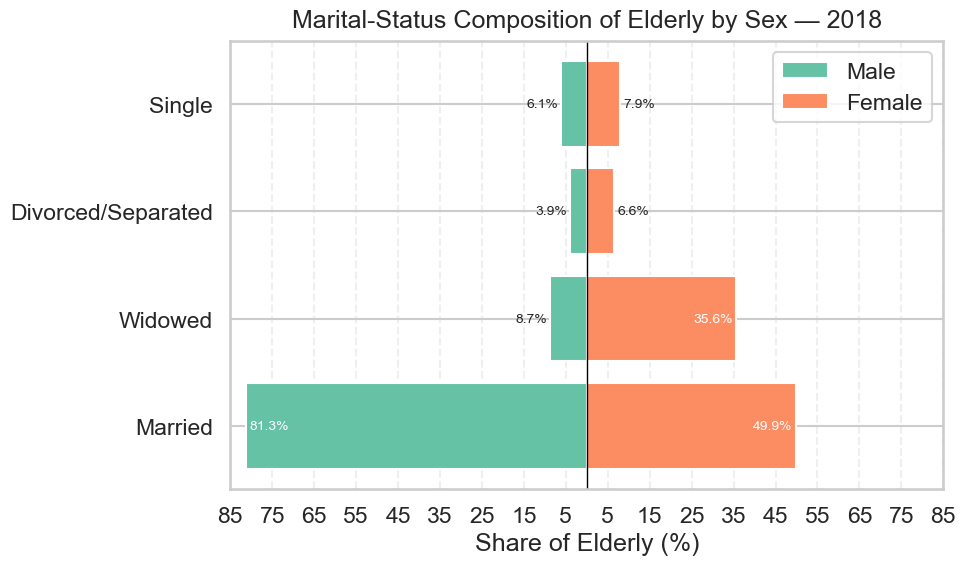

```python
# ---------------------------------------------------------
# 3) Helper: get latest-year elderly slice with Male/Female only
# ---------------------------------------------------------
def get_latest_elderly(frame):
    elderly = frame[frame["elderly_pop"] == "Elderly"].copy()       # Keep elderly only
    latest_year = int(elderly["shs_year"].max())                    # Find most recent year
    latest = elderly[elderly["shs_year"] == latest_year].copy()     # Filter to latest year
    latest = latest[latest["sex"].isin(["Male", "Female"])].copy()  # Keep Male/Female (drop 'All')
    latest["marital_status"] = latest["marital_status"].astype(str) # Ensure string labels
    return latest, latest_year                                      # Return slice + year

# ---------------------------------------------------------
# 4) Helper: reshape to wide (index=status, columns=sex, values=%)
# ---------------------------------------------------------
def to_status_by_sex(latest):
    piv = (latest.pivot_table(index="marital_status", columns="sex",
                              values="percentage", aggfunc="mean")  # Average if duplicates exist
                 .fillna(0.0))                                      # Fill missing with 0
    # Ensure all expected statuses appear in a logical order
    order = ["Married", "Widowed", "Divorced/Separated", "Single"]  # Desired order
    for s in order:                                                 # Add missing rows as 0s if absent
        if s not in piv.index:
            piv.loc[s, ["Male","Female"]] = 0.0
    piv = piv.loc[order]                                            # Reorder rows
    return piv                                                       # Return wide matrix

# ---------------------------------------------------------
# 5) Helper: add value labels on bars (inside if wide enough)
# ---------------------------------------------------------
def add_value_labels(ax, bars, fmt="{:.1f}%"):
    for b in bars:                                                  # Loop through bar containers
        width = b.get_width()                                       # Signed width (neg for Male)
        y = b.get_y() + b.get_height() / 2                          # Vertical center
        txt = fmt.format(abs(width))                                 # Show absolute value with %
        if abs(width) >= 12:                                         # If bar long enough, draw inside
            ax.text(width - np.sign(width)*0.8, y, txt, va="center",
                    ha="right" if width > 0 else "left", color="white", fontsize=10)
        else:                                                        # Otherwise, draw just outside
            ax.text(width + np.sign(width)*0.8, y, txt, va="center",
                    ha="left" if width > 0 else "right", fontsize=10)

# ---------------------------------------------------------
# 6) Helper: pretty axis + center line
# ---------------------------------------------------------
def format_pyramid_axes(ax, max_pct=100):
    lim = max(20, min(100, int(np.ceil(max_pct/5)*5)))              # Sensible bound (nearest 5)
    ax.set_xlim(-lim, lim)                                          # Symmetric x-limits
    xt = list(range(-lim, lim+1, 10))                               # Tick marks every 10
    ax.set_xticks(xt)                                               # Set x ticks
    ax.set_xticklabels([f"{abs(t)}" for t in xt])                   # Show absolute values on ticks
    ax.axvline(0, color="black", linewidth=1)                       # Center spine at zero
    ax.grid(axis="x", linestyle="--", alpha=0.3)                    # Light vertical grid

# ---------------------------------------------------------
# 7) Build latest-year slice and wide table
# ---------------------------------------------------------
latest, latest_year = get_latest_elderly(df)                        # Get latest elderly data
piv = to_status_by_sex(latest)                                      # Wide: status × sex

# ---------------------------------------------------------
# 8) Prepare plotting data (Male negative, Female positive)
# ---------------------------------------------------------
male_vals = -piv["Male"].to_numpy()                                 # Negate for left side
fem_vals  =  piv["Female"].to_numpy()                               # Positive for right side
statuses  = piv.index.tolist()                                      # Y-axis categories
y_pos     = np.arange(len(statuses))                                 # Numeric y positions
max_pct   = float(np.max(np.abs(np.concatenate([male_vals, fem_vals]))))  # Max magnitude

# ---------------------------------------------------------
# 9) Plot population pyramid
# ---------------------------------------------------------
sns.set_theme(style="whitegrid", context="talk")                    # Nice styling
fig, ax = plt.subplots(figsize=(10, 6))                             # Create figure

bars_left  = ax.barh(y_pos, male_vals,  color=sns.color_palette("Set2")[0], label="Male")    # Left bars
bars_right = ax.barh(y_pos, fem_vals,   color=sns.color_palette("Set2")[1], label="Female")  # Right bars

ax.set_yticks(y_pos)                                                # Set y ticks
ax.set_yticklabels(statuses)                                       # Apply status labels
ax.set_xlabel("Share of Elderly (%)")                               # X-axis label
ax.set_title(f"Marital-Status Composition of Elderly by Sex — {latest_year}", pad=10)  # Title
ax.legend(loc="upper right")                                        # Legend in corner

format_pyramid_axes(ax, max_pct=max_pct)                            # Symmetric axes + grid
add_value_labels(ax, bars_left,  fmt="{:.1f}%")                     # Labels on male bars
add_value_labels(ax, bars_right, fmt="{:.1f}%")                     # Labels on female bars

plt.tight_layout()                                                  # Layout pass
plt.show()                                                          # Render chart
```

This graph shows the marital status composition of elderly men and women in 2018. Among elderly men, the overwhelming majority are married (81.3%), with smaller proportions being widowed (8.7%), single (6.1%), or divorced/separated (3.9%). In contrast, elderly women are much more varied in marital status: while about half are married (49.9%), a very large share are widowed (35.6%), followed by smaller groups who are single (7.9%) or divorced/separated (6.6%). The most striking difference between men and women is in widowhood: far more elderly women are widowed compared to men, which reflects women’s generally longer life expectancy and the tendency for them to outlive their husbands. Overall, the chart highlights that elderly men are most likely to still be married in their later years, while elderly women have a significantly higher likelihood of being widowed due to them outliving men.

https://ourworldindata.org/why-do-women-live-longer-than-men  
https://www.scientificamerican.com/article/why-is-life-expectancy-lo/  
https://www.bbc.com/future/article/20151001-why-women-live-longer-than-men  
https://wifehealth.com/why-is-female-life-expectancy-higher-than-male/

These are all the sources i can find why women live longer than man. Out of all these sources one common find is that women live longer because of harmonal changes "Estrogen’s Cardiovascular Benefits: Estrogen is thought to have protective effects on the cardiovascular system. It helps maintain healthy blood vessels, reduces bad cholesterol (LDL), and improves overall heart health. This hormonal advantage likely contributes to the lower rates of heart disease in women compared to men, especially at younger ages."

# Question 8: “How has the distribution of elderly residents across housing tenure types changed between 2013 and the most recent year?”

```python
# ---------------------------
# 1) Load dataset and clean column names
# ---------------------------
df = pd.read_csv("HDBElderlyandFutureElderlyResidentPopulationbyTenureType.csv")  # Read CSV into DataFrame


# ---------------------------
# 2) Print basic dataset information
# ---------------------------
print("Shape of dataset:", df.shape)                                                 # Number of rows and columns
print("\nColumn Names:", df.columns.tolist())                                        # List of all column names
print("\nData Types:\n", df.dtypes)                                                  # Data type of each column
print("\nFirst 5 Rows:\n", df.head())                                                # Preview first 5 rows


# ---------------------------
# 3) Explore unique values and ranges
# ---------------------------
print("\nUnique years:", df["shs_year"].unique())                                    # Distinct years
print("Year range:", (df["shs_year"].min(), df["shs_year"].max()))                   # Minimum and maximum year
print("Unique elderly_pop values:", df["elderly_pop"].unique())                      # Elderly vs Future Elderly
print("Unique tenure types:", df["tenure_type"].unique())                            # Tenure categories


# ---------------------------
# 6) Summary statistics using Pandas (percentage column)
# ---------------------------
print("\nOverall percentage statistics:")                                             # Print basic stats
print(" Mean:", df["percentage"].mean())                                              # Mean percentage
print(" Median:", df["percentage"].median())                                          # Median percentage
print(" Minimum:", df["percentage"].min())                                            # Smallest percentage
print(" Maximum:", df["percentage"].max())                                            # Largest percentage
print(" Std Dev:", df["percentage"].std())                                            # Standard deviation


# ---------------------------
# 7) Per-tenure-type summary statistics (all rows)
# ---------------------------
print("\nMean % by tenure type (all rows):")                                          # Mean % for each tenure type
print(df.groupby("tenure_type")["percentage"].mean().round(2))

print("\nMedian % by tenure type (all rows):")                                        # Median % for each tenure type
print(df.groupby("tenure_type")["percentage"].median().round(2))
```

```
Shape of dataset: (24, 4)

Column Names: ['shs_year', 'elderly_pop', 'tenure_type', 'percentage']

Data Types:
 shs_year         int64
elderly_pop     object
tenure_type     object
percentage     float64
dtype: object

First 5 Rows:
    shs_year     elderly_pop tenure_type  percentage
0      2003         Elderly        Sold        90.4
1      2003         Elderly      Rental         9.6
2      2003  Future Elderly        Sold        95.1
3      2003  Future Elderly      Rental         4.9
4      2003             All        Sold        97.1

Unique years: [2003 2008 2013 2018]
Year range: (2003, 2018)
Unique elderly_pop values: ['Elderly' 'Future Elderly' 'All']
Unique tenure types: ['Sold' 'Rental']

Overall percentage statistics:
 Mean: 50.0
 Median: 50.0
 Minimum: 2.9
 Maximum: 97.1
 Std Dev: 45.73816786885981

Mean % by tenure type (all rows):
tenure_type
Rental     5.28
Sold      94.72
Name: percentage, dtype: float64

Median % by tenure type (all rows):
tenure_type
Rental     4.7
Sold      95.3
Name: percentage, dtype: float64
```

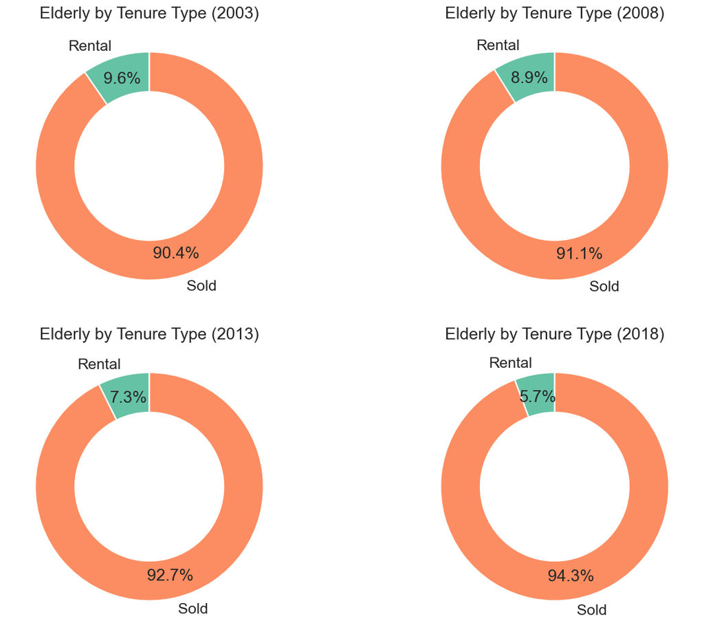

```python
# ---------------------------------------------
# 0) Load data and keep Elderly only
# ---------------------------------------------
df = pd.read_csv("HDBElderlyandFutureElderlyResidentPopulationbyTenureType.csv")  # Load dataset from CSV
elderly = df[df["elderly_pop"] == "Elderly"].copy()                               # Filter rows where elderly_pop is "Elderly"

# ---------------------------------------------
# 1) Pick 4 representative years (earliest → latest)
#    (Evenly spaced across what's available)
# ---------------------------------------------
years = np.sort(elderly["shs_year"].unique())        # Get all unique years, sorted ascending
idx = np.linspace(0, len(years) - 1, 4)              # Pick 4 evenly spaced positions (indices) across range
years4 = years[idx.round().astype(int)]              # Convert positions to integer indices → select 4 years

# ---------------------------------------------
# 2) Helper: % share by tenure_type for a given year
# ---------------------------------------------
def get_year_share(frame, year):                     # Define a function to calculate % share by tenure_type
    sub = frame[frame["shs_year"] == year]           # Filter dataset for that year
    return sub.groupby("tenure_type")["percentage"].sum()  # Group by tenure_type, sum percentages for each group

# ---------------------------------------------
# 3) Build aligned series (same category order/colors)
# ---------------------------------------------
cats = sorted(elderly["tenure_type"].dropna().unique().tolist())  # Get all unique tenure types (sorted alphabetically)
palette = sns.color_palette("Set2", n_colors=len(cats))           # Generate a color palette with 1 color per category
color_map = dict(zip(cats, palette))                              # Map each category to a consistent color

series_list = []                                                  # Empty list to store (year, data) pairs
for y in years4:                                                  # Loop over the 4 selected years
    s = get_year_share(elderly, y).reindex(cats, fill_value=0)    # Get shares for that year, reindex to fixed category order
    series_list.append((y, s))                                    # Append (year, Series of values) to list

# ---------------------------------------------
# 4) Plot 4 pies (2x2) with light Seaborn styling
# ---------------------------------------------
sns.set_theme(style="whitegrid", context="talk")                  # Apply Seaborn theme for clean look

fig, axes = plt.subplots(2, 2, figsize=(14, 10))                  # Create a 2x2 grid of subplots (big figure)
axes = axes.ravel()                                               # Flatten axes array → easier iteration

wedgeprops = dict(width=0.35, edgecolor="white")                  # Style wedges (thinner width → donut look)

for ax, (y, s) in zip(axes, series_list):                         # Loop over subplots and year/data pairs
    colors = [color_map[c] for c in s.index]                      # Pick colors for each category in fixed order
    ax.pie(                                                       # Draw pie chart for that year
        s.values,                                                 # Values (percentages per tenure type)
        labels=s.index,                                           # Labels (tenure type names)
        autopct="%1.1f%%",                                        # Show values as % with 1 decimal place
        startangle=90,                                            # Rotate so first wedge starts at top
        colors=colors,                                            # Apply consistent colors across years
        wedgeprops=wedgeprops,                                    # Apply donut style + white edges
        pctdistance=0.8                                           # Push % labels slightly outward
    )
    ax.set_title(f"Elderly by Tenure Type ({y})")                 # Title for each subplot
    ax.set(aspect="equal")                                        # Keep aspect ratio square → perfect circle

plt.tight_layout()                                                # Adjust layout to prevent overlap
plt.show()                                                        # Render the final plot
```

The four donut charts show the tenure type of elderly households across 2003, 2008, 2013, and 2018, split into rental flats and sold flats. In every year, the vast majority of elderly live in sold flats, while only a small minority live in rental flats. In 2003, 90.4% of elderly were in sold flats and 9.6% in rental flats. This rental share gradually declined over time: 8.9% in 2008, 7.3% in 2013, and just 5.7% in 2018. Conversely, the share of elderly in sold flats rose steadily, reaching 94.3% in 2018. Overall, the charts highlight a clear trend where ownership of sold flats among the elderly has become increasingly dominant, while the proportion relying on rental flats has steadily decreased across the 15-year period.